# TOD Evaluation in Chicago

## Poverty Rate

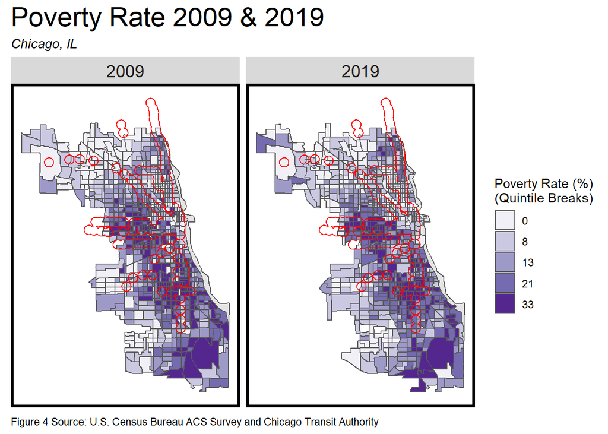

```r
ggplot(Chicago_selected)+
    geom_sf(data = st_union(Chicago_Census_Tract_B))+
    geom_sf(aes(fill = q5(pctPoverty.inf))) +
    geom_sf(data = buffer, fill = "transparent", color = "red")+
    scale_fill_brewer(palette = "Purples",
                      labels = qBr(Chicago_selected, "pctPoverty.inf"),
                      name = "Poverty Rate (%)\n(Quintile Breaks)") +
    labs(title = "Poverty Rate 2009 & 2019", subtitle = "Chicago, IL", caption = "Figure 4 Source: U.S. Census Bureau ACS Survey and Chicago Transit Authority") +
    facet_wrap(~year)+
    mapTheme() +
    theme(plot.title = element_text(size=22))
```

## Education Rate (Bachelor or above)

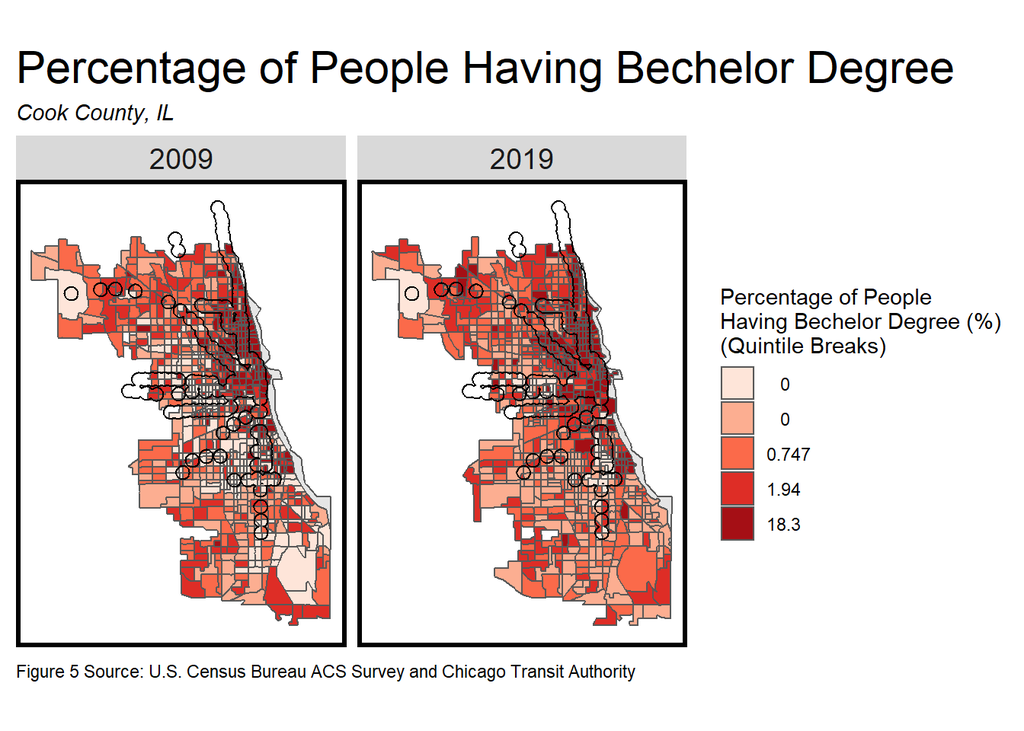

```r
ggplot(Chicago_selected)+
    geom_sf(data = st_union(Chicago_Census_Tract_B))+
    geom_sf(aes(fill = q5(pctBachelors.inf))) +
    geom_sf(data = buffer, fill = "transparent", color = "black")+
    scale_fill_brewer(palette = "Reds",
                      labels = qBr2(Chicago_selected, "pctBachelors.inf",rnd=FALSE),
                      name = "Percentage of People\nHaving Bechelor Degree (%)\n(Quintile Breaks)") +
    labs(title = "Percentage of People Having Bechelor Degree", subtitle = "Cook County, IL", caption = "Figure 5 Source: U.S. Census Bureau ACS Survey and Chicago Transit Authority") +
    facet_wrap(~year)+
    mapTheme() +
    theme(plot.title = element_text(size=22))
```

Notice that we could see huge economic disparities in Chicago between its North and South side. Household income and land value are much higher in the North side, and have continued to rise in ten years. Poverty Rate was much severe in the South, and is still severe after ten years. It is important to study both sides in depth. This may skew our TOD analysis later: if we see an increase in income around TOD areas, does this increase only appear in one side of the region?

## Summary Table Grouped by TOD and Non-TOD areas

```r
Chicago_selected.Summary <-
  st_drop_geometry(Chicago_selected) %>%
    group_by(year, TOD) %>%
    summarize(Total_Population = mean(Total_Pop,na.rm = T),
              Median_Rent = mean(Med_Rent.inf, na.rm = T),
              Median_HH_Income = mean(MedHHInc.inf, na.rm = T),
              Percent_Bach = mean(pctBachelors.inf, na.rm = T),
              Percent_Poverty = mean(pctPoverty.inf, na.rm = T))

Chicago_selected.Summary %>%
  unite(year.TOD, year, TOD, sep = ": ", remove = T) %>%
  gather(Variable, Value, -year.TOD) %>%
  mutate(Value = round(Value, 2)) %>%
  spread(year.TOD, Value) %>%
  kable() %>%
    kable_styling() %>%
    footnote(general_title = "\n",
             general = "Table 1")
```

[output not shown]

From the graphs and the table above, we could see that there is an increase in population in TOD areas between 2009 and 2019, indicating that more people are willing to move into TOD area with slightly an higher rent, while population in non-TOD areas remained similar. We could also observe a decrease in poverty rate, and a growth in both income and education level in the city in general between 2009 and 2019.

## Plot Indicators grouped by TOD and Non-TOD areas

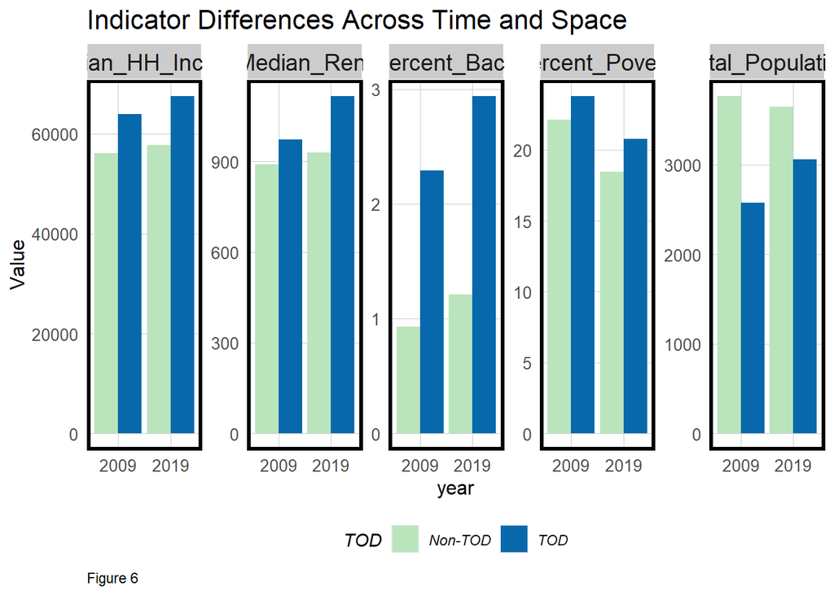

```r
Chicago_selected.Summary %>%
  gather(Variable, Value, -year, -TOD) %>%
  ggplot(aes(year, Value, fill = TOD)) +
    geom_bar(stat = "identity", position = "dodge") +
    facet_wrap(~Variable, scales = "free", ncol=5) +
    scale_fill_manual(values = c("#bae4bc", "#0868ac")) +
    labs(title = "Indicator Differences Across Time and Space", caption = ("Figure 6")) +
    plotTheme() + theme(legend.position="bottom")
```

Notice the rent in TOD areas has increased faster than the rent in non-TOD areas within these ten years, indicating that transit accessibility might be a major factor affecting housing market. On the other hand, the population has increased in TOD areas but decreased in non-TOD area, again showing that people are willing to pay higher rent with better transit accessibility. Other variables have a relative proportional increase in tens. People live in TOD areas usually have higher income and received better education.

# Population and Median Rent within 0.5 miles of L stops (Graduated Symbol Maps)

The graduated symbol graphs could give a more direct view on population size and household median rent using circle size within TOD areas (1/2 miles radius around L stops). We will look at the population and rent in 2019.

## Population

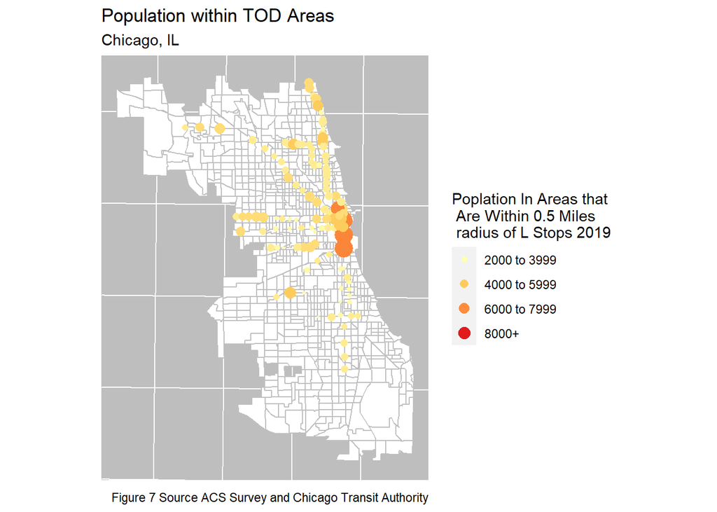

```r
library(RColorBrewer)
new_Lstops <- Chicago_L_Stops
new_Lstops <- st_join(Chicago_L_Stops, Chicago_selected, join = st_intersects) %>%
  filter(year == "2019") %>%
  na.omit()

ggplot()+
  geom_sf(data = Chicago_selected,fill= "white", color="grey75")+
  geom_sf(data = new_Lstops %>%
            st_centroid(),
     shape = 21, color="transparent",
     aes(size = Total_Pop, fill = Total_Pop))+
  scale_size_continuous(
     range = c(0,6),
     breaks = c(0,2000,4000,6000,8000),
     labels = c("0 to 1999", "2000 to 3999", "4000 to 5999", "6000 to 7999","8000+"),
     name="Poplation In Areas that\n Are Within 0.5 Miles\n radius of L Stops 2019")+
  scale_fill_stepsn(
     colors = RColorBrewer::brewer.pal(4, name="YlOrRd"),
     breaks=c(0,2000,4000,6000,8000),
     guide=FALSE)+
  labs(title = "Population within TOD Areas", caption = "Figure 7 Source ACS Survey and Chicago Transit Authority", subtitle = "Chicago, IL") +
  theme(axis.title=element_blank(),
     axis.text=element_blank(), axis.ticks=element_blank(),
     panel.background = element_rect(fill='gray'))+
  guides(
     size = guide_legend(override.aes = list(fill = brewer.pal(4,   name="YlOrRd"))))
```

## Median Household Rent

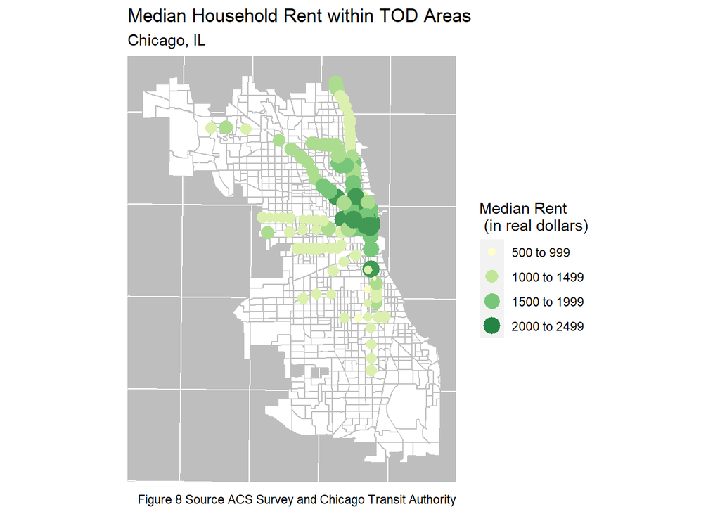

```r
ggplot()+
  geom_sf(data = Chicago_selected,fill= "white", color="grey75")+
  geom_sf(data = new_Lstops %>%
            st_centroid(),
     shape = 21, color="transparent",
     aes(size = Med_Rent, fill = Med_Rent))+
  scale_size_continuous(
     range = c(1,6),
     breaks = c(0,500,1000,1500,2000,2500),
     labels = c("0 to 499", "500 to 999", "1000 to 1499", "1500 to 1999","2000 to 2499","2500+"),
     name="Median Rent\n (in real dollars)")+
  scale_fill_stepsn(
     colors = RColorBrewer::brewer.pal(4, name="YlGn"),
     breaks=c(0,500,1000,1500,2000,2500),
     guide=FALSE)+
  labs(title = "Median Household Rent within TOD Areas", caption = "Figure 8 Source ACS Survey and Chicago Transit Authority", subtitle = "Chicago, IL") +
  theme(axis.title=element_blank(),
     axis.text=element_blank(), axis.ticks=element_blank(),
     panel.background = element_rect(fill='gray'))+
  guides(
     size = guide_legend(override.aes = list(fill = brewer.pal(4,   name="YlGn"))))
```

In summary, population is concentrated at the city center; it also has the highest rent. In addition, we can see a clear difference in the North and South side of Chicago. North Chicago has much higher number of residents and extensively higher rent.

# Geomline Plot Camparing Rent against distance away from L Stops

We will access weather the rent is higher when the unit is closer to a transit stop using Geomline Plot.

## Setting up Multiple Ring Buffer Function

```r
  multipleRingBuffer <- function(inputPolygon, maxDistance, interval)
{
  #create a list of distances that we'll iterate through to create each ring
  distances <- seq(0, maxDistance, interval)
  #we'll start with the second value in that list - the first is '0'
  distancesCounter <- 2
  #total number of rings we're going to create
  numberOfRings <- floor(maxDistance / interval)
  #a counter of number of rings
  numberOfRingsCounter <- 1
  #initialize an otuput data frame (that is not an sf)
  allRings <- data.frame()

  #while number of rings  counteris less than the specified nubmer of rings
  while (numberOfRingsCounter <= numberOfRings)
  {
    #if we're interested in a negative buffer and this is the first buffer
    #(ie. not distance = '0' in the distances list)
    if(distances[distancesCounter] < 0 & distancesCounter == 2)
    {
      #buffer the input by the first distance
      buffer1 <- st_buffer(inputPolygon, distances[distancesCounter])
      #different that buffer from the input polygon to get the first ring
      buffer1_ <- st_difference(inputPolygon, buffer1)
      #cast this sf as a polygon geometry type
      thisRing <- st_cast(buffer1_, "POLYGON")
      #take the last column which is 'geometry'
      thisRing <- as.data.frame(thisRing[,ncol(thisRing)])
      #add a new field, 'distance' so we know how far the distance is for a give ring
      thisRing$distance <- distances[distancesCounter]
    }


    #otherwise, if this is the second or more ring (and a negative buffer)
    else if(distances[distancesCounter] < 0 & distancesCounter > 2)
    {
      #buffer by a specific distance
      buffer1 <- st_buffer(inputPolygon, distances[distancesCounter])
      #create the next smallest buffer
      buffer2 <- st_buffer(inputPolygon, distances[distancesCounter-1])
      #This can then be used to difference out a buffer running from 660 to 1320
      #This works because differencing 1320ft by 660ft = a buffer between 660 & 1320.
      #bc the area after 660ft in buffer2 = NA.
      thisRing <- st_difference(buffer2,buffer1)
      #cast as apolygon
      thisRing <- st_cast(thisRing, "POLYGON")
      #get the last field
      thisRing <- as.data.frame(thisRing$geometry)
      #create the distance field
      thisRing$distance <- distances[distancesCounter]
    }

    #Otherwise, if its a positive buffer
    else
    {
      #Create a positive buffer
      buffer1 <- st_buffer(inputPolygon, distances[distancesCounter])
      #create a positive buffer that is one distance smaller. So if its the first buffer
      #distance, buffer1_ will = 0.
      buffer1_ <- st_buffer(inputPolygon, distances[distancesCounter-1])
      #difference the two buffers
      thisRing <- st_difference(buffer1,buffer1_)
      #cast as a polygon
      thisRing <- st_cast(thisRing, "POLYGON")
      #geometry column as a data frame
      thisRing <- as.data.frame(thisRing[,ncol(thisRing)])
      #add teh distance
      thisRing$distance <- distances[distancesCounter]
    }

    #rbind this ring to the rest of the rings
    allRings <- rbind(allRings, thisRing)
    #iterate the distance counter
    distancesCounter <- distancesCounter + 1
    #iterate the number of rings counter
    numberOfRingsCounter <- numberOfRingsCounter + 1
  }

  #convert the allRings data frame to an sf data frame
  allRings <- st_as_sf(allRings)
}
```

## Creating Multiple Ring Buffer around L stops

```r
Chicago_selected %>%
  st_transform('EPSG:26916')

Chicago_all.rings <-
  st_join(st_centroid(dplyr::select(Chicago_selected, GEOID, year)),
          multipleRingBuffer(buffer, 11265, 804)) %>%
  st_drop_geometry() %>%
  left_join(dplyr::select(Chicago_selected, GEOID, Med_Rent, year),
            by=c("GEOID"="GEOID", "year"="year")) %>%
  st_sf() %>%
    na.omit()%>%
    mutate(distance = distance / 1609.34)
```

## Plotting Geomline

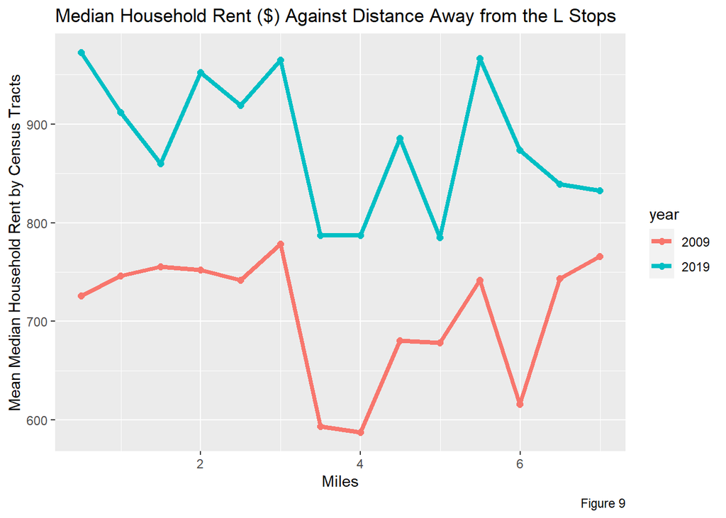

```r
Ring.Sum <- Chicago_all.rings %>%
  st_drop_geometry()%>%
  group_by(year,distance)%>%
  summarize(Mean_Med_rent = mean (Med_Rent,na.rm=T))


ggplot(data=Ring.Sum, aes(x=distance, y=Mean_Med_rent, color=year)) +
  geom_line(size=1.5)+
  geom_point(size=2)+
  labs(title="Median Household Rent ($) Against Distance Away from the L Stops", caption = ("Figure 9"))+
  xlab("Miles")+
  ylab("Mean Median Household Rent by Census Tracts")
```

The data in 2009 seems to be less dramatic first few miles away from the stops; the data in 2019 is more fluctuating. Interestingly, in 2009, the highest rent occurs 3 miles away from the L stops; in 2019, it occurs at a distance very close to the stops. This observation could mean that TOD has played a role in rising rent prices in Chicago.

Another interesting observation is at 7 miles away from the stops, 2009 and 2019 data sets show opposite results in rents. Perhaps, multiple major development projects took place somewhere 7 miles away from the stops in ten years.

# Crime Data of Chicago in 2009 and 2019

The offense type chosen is pocket-picking. Since people live in TOD areas generally have higher income and pay higher, would this fact provide a ground for more theft-related crimes to be committed?

## Getting Crime Data

```r
library(crimedata)
library(lubridate)

Chicago_Crime_2009 <- get_crime_data(cities = "Chicago",
                         years = 2009,
                         type = "core",
                         output = "sf") %>%
  filter(offense_type=="pocket-picking")

Chicago_Crime_2019 <- get_crime_data(cities = "Chicago",
                         years = 2019,
                         type = "core",
                         output = "sf") %>%
  filter(offense_type=="pocket-picking")

crime_both_year <- rbind(Chicago_Crime_2009,Chicago_Crime_2019) %>%
  st_transform(st_crs(Chicago_selected))
```

## Count Crime in Census Tracts

```r
Crime_in_Census_Tract <-st_join(crime_both_year,Chicago_selected)

Crime_Count <- count(as_tibble(Crime_in_Census_Tract),GEOID)

Re_Join_Crime_withSF <- left_join(Crime_in_Census_Tract,Crime_Count,by = "GEOID")%>%
  rename("Crime_Count" = n)%>%
  select(-uid, -city_name, -offense_code, -longitude, -latitude,-census_block, -offense_type, -offense_group, -offense_against, -date_single,-location_type, -location_category)

Re_Join_Crime_withSF2 <- na.omit(Re_Join_Crime_withSF) %>%
  st_drop_geometry()%>%
  left_join(Chicago_selected, Re_Join_Crime_withSF, by = "GEOID")%>%
  st_sf()
```

## Crime Count in TOD Census Tract

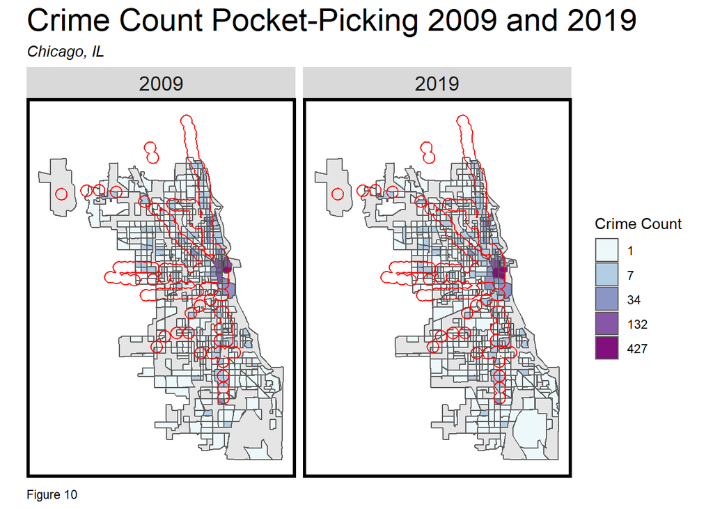

```r
ggplot(Re_Join_Crime_withSF2)+
    geom_sf(data = st_union(Chicago_Census_Tract_B))+
    geom_sf(aes(fill = q5(Crime_Count))) +
    geom_sf(data = buffer, fill = "transparent", color = "red")+
    scale_fill_brewer(palette = "BuPu",
                      labels = qBr(Re_Join_Crime_withSF,"Crime_Count"),
                      name = "Crime Count") +
    labs(title = "Crime Count Pocket-Picking 2009 and 2019", subtitle = "Chicago, IL", caption = "Figure 10") +
    facet_wrap(~year.x)+
    mapTheme() +
    theme(plot.title = element_text(size=22))
```

Most cases are concentrated at the city center, and the rest sparsely spreads evenly throughout the city.

## Crime and Other TOD Indicators Summary Table

```r
Chicago_Crime.Summary <-
  Re_Join_Crime_withSF %>%
  na.omit() %>%
   st_drop_geometry() %>%
    group_by(year, TOD) %>%
    summarize(Total_Population = mean(Total_Pop,na.rm = T),
              Median_Rent = mean(Med_Rent.inf, na.rm = T),
              Median_HH_Income = mean(MedHHInc.inf, na.rm = T),
              Percent_Bach = mean(pctBachelors.inf, na.rm = T),
              Percent_Poverty = mean(pctPoverty.inf, na.rm = T),
              Crime_Pocket_Picking_Count=mean(Crime_Count, na.rm =T))

Chicago_Crime.Summary %>%
  unite(year.TOD, year, TOD, sep = ": ", remove = T) %>%
  gather(Variable, Value, -year.TOD) %>%
  mutate(Value = round(Value, 0)) %>%
  spread(year.TOD, Value) %>%
  kable() %>%
    kable_styling() %>%
    footnote(general_title = "\n",
             general = "Table 2 TOD Indicators with Various Variables, including crime number")
```

[output not shown]

## Geomline Plot Camparing Crime against Distance Away From L stops

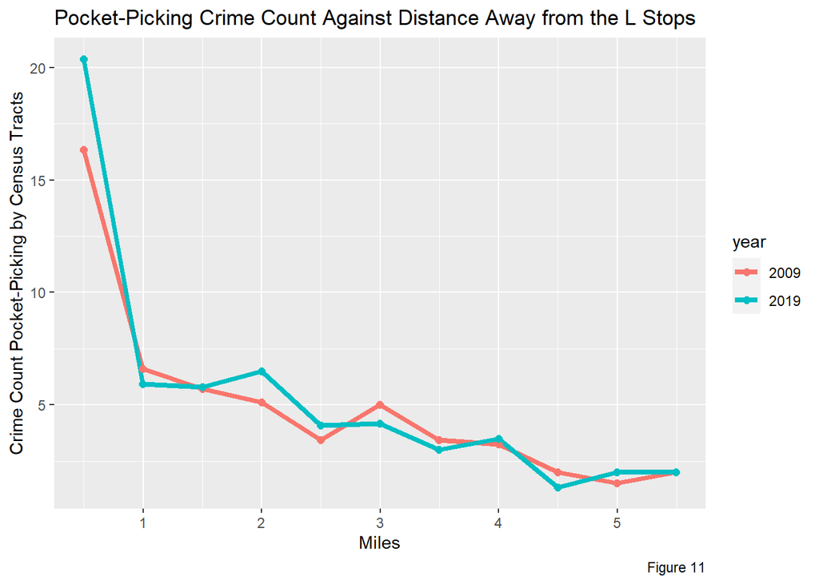

```r
Chicago_selected <- Chicago_selected %>%
  st_transform('EPSG:26916')

Chicago_all.rings.crime <-
  st_join(st_centroid(dplyr::select(Chicago_selected, GEOID, year)),
          multipleRingBuffer(buffer, 11265, 804)) %>%
  st_drop_geometry() %>%
  left_join(dplyr::select(Re_Join_Crime_withSF, GEOID, Crime_Count, year),
            by=c("GEOID"="GEOID", "year"="year")) %>%
  st_sf() %>%
    na.omit()%>%
    mutate(distance = distance / 1609.34)

Ring.Sum2 <- Chicago_all.rings.crime %>%
  st_drop_geometry()%>%
  group_by(year,distance)%>%
  summarize(Crime = mean (Crime_Count,na.rm=T))


ggplot(data=Ring.Sum2, aes(x=distance, y=Crime, color=year)) +
  geom_line(size=1.5)+
  geom_point(size=2)+
  labs(title="Pocket-Picking Crime Count Against Distance Away from the L Stops",caption = ("Figure 11"))+
  xlab("Miles")+
  ylab("Crime Count Pocket-Picking by Census Tracts")
```

## Comparing Changes within Indicators between 2009 and 2019

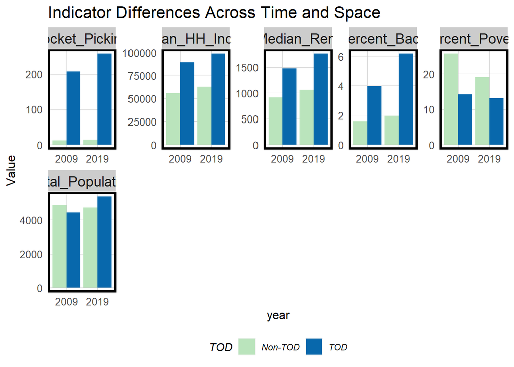

```r
Chicago_Crime.Summary %>%
  gather(Variable, Value, -year, -TOD) %>%
  ggplot(aes(year, Value, fill = TOD)) +
    geom_bar(stat = "identity", position = "dodge") +
    facet_wrap(~Variable, scales = "free", ncol=5) +
    scale_fill_manual(values = c("#bae4bc", "#0868ac")) +
    labs(title = "Indicator Differences Across Time and Space") +
    plotTheme() + theme(legend.position="bottom")
```

We can see from above, as rent increases, the crime also increases.

## Conclusion: Is Chicago Good for TOD?

Overall, this brief shows Chicago as a good candidate for TOD. People are willing to pay more rent to have easier access to transits. This trend can be shown through the fast increase in population around TOD area between 2009-2019, even though the rent is higher, while population in non-TOD area remains similar. TOD is also associated with reduced poverty, higher education level, higher income level. However, these patterns can be seen in non-TOD areas as well, therefore these variables might be less correlated with access to transit than the development of city as a whole. This analysis does not provide an adequate crime data to determine the relationship between crime and TOD. More crime types need to be assessed and the neighborhood effects need to be considered as well.

We also have to pay attention to the inequity in Chicago. The land value seems to be much lower in the South side than the North side throughout these 10 years, regardless of the access to transit. An in-depth study between these sides are necessary. TOD holds equity development as a core value; it won’t be effective when it only benefits one group of people. In addition, we could see that transit extends to North and West much more than to the South, meaning there are people living in South Chicago who have no access to transits at all.